# Gesamtauswertung der Zyklen 1-6 der Legierung CMSX10

Stephan Rietzler

# Viscosity

## Graphische Analyse

In folgendem Plot sind die ermittelten Viskositäts-Wert gegen die Temperatur aufgetragen. Zusätzlich eingezeichnet ist ein in der Temperatur linearer und quadratischer Fit an die Daten.

**Folgerung:**

- Zuerst fällt auf das Datenpunkte die als ‘nicht-plausibel’ bewertet wurden nicht in das Bild ‘passen’. D.h. Werte bei denen das Intervall Schätzwert $\pm$ 3*Standardfehler die Null enthält, oder anders formuliert: Werte die nur mit einer sehr hohen Unsicherhteit geschätzt wurden. Diese werden im folgenden herausgenommen.

**Viskosität vs. Temperatur für ‘plausible’ Werte**

**Folgerung**

- Bei hohen Temperaturen sind wenig Daten vorhanden. Das liegt daran, das die meisten Signale am Anfang stark verrauscht waren und deswegen eine Schätzung der Dämpfung nicht zuverlässig möglich war.
- Der Zusammenhang zwischen Viskosität und Temperatur lässt sich aufgrund der wenigen Daten schlecht ermitteln. Die vorhandenen Daten bieten zudem kein konsitentes Bild.
- Da bei den ersten drei Zyklen die Temperatur-Erfassung nicht fehlerfrei war werden explorative diese mal ausgenommen:

**Viskosität vs. Temperatur für ‘plausible’ Werte und Zyklen mit nicht fehlerhafter Temperaturmessung**

[figure not shown]

Schließt man also alle zweifelhaften Werte aus, so erhält man aus den Zyklen 1-6 nur 8 einigermaßen zuverlässige Schätzwerte für die Viskosität.

Eine zuverlässige Prüfung ob der Zusammenhang zwischen Viskosität und Temperatur nichtlinear ist ist damit eigentlich nicht mehr möglich. Aus diesem Grund wird im foglenden nur das Modell für den linearen Zusammenhang untersucht.

Gegenübergestellt werden allerding die Ergebnisse für alle plausiblen Ergebnisse vs. nur den Ergebnissen aus den Zyklen 4-6 für welche die Temperatur messung zuverlässig war.

## Numerische Analyse

Die Daten werden so umskaliert, das der Temperatur-Nullpunkt der Schmelztemperatur von CMSX10 (1433 °C) entspricht. Die bei ‘Intercept’ angegebene Größe entspricht damit der Viskosität am Schmelzpunkt.

**Anpassung einer linearen Funktion an alle plausiblen Werte:**

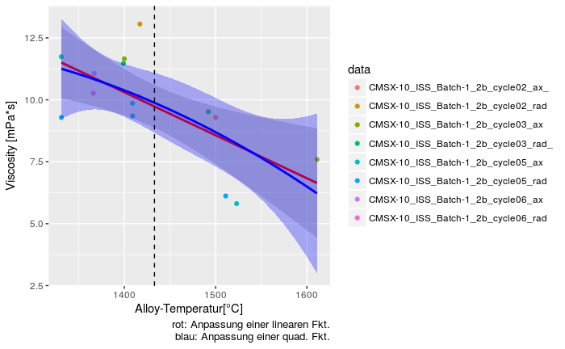

**Anpassung einer linearen Funktion an alle plausiblen Werte der Zyklen 4-6:**

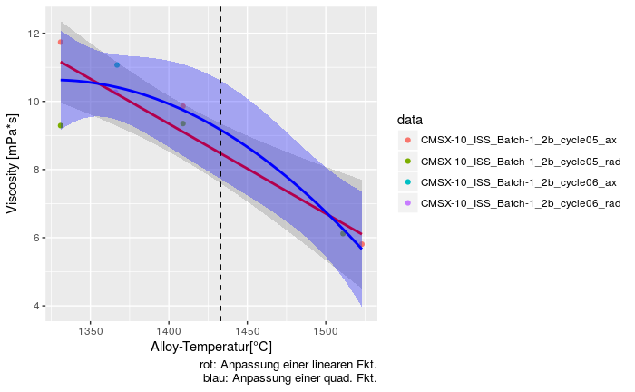

**Folgerung:**

# Surface-Tension

## Graphische Analyse

[output not shown]

[output not shown]

Die Streuung wird dadurch aber nicht offensichtlich reduziert.

## Numerische Analyse

Auch hier wird wieder ein lineares und quadratisches Modell gefittet um zu untersuchen ob der Zusammenahng zwischen Oberflächenspannung und Temperatur durch ein nichtlineares Modell besser beschrieben wird.

**Anpassung einer linearen Funktion an alle Daten**

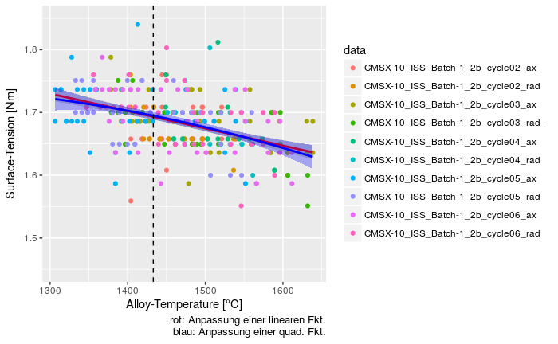

**Anpassung einer linearen Funktion an Daten mit zuverlässiger Temperturmessung**

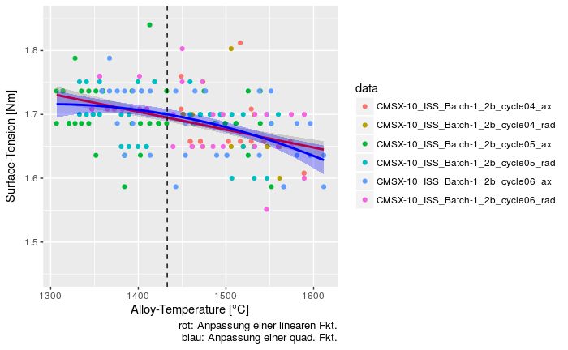

# Anhang: Summary der verwendeten Datensätze

- In der Auswertungssoftware gesetzte Parameter und dort vermerkte Kommentare zur Auswertung sind in den folgenden Abschnitten für jeden untersuchten Datensatz aus den Zyklen 1-6 gelistet.
- Die verwendeten Rohdaten (Ergebnisse aus der Auswertungssoftware) sind als csv Dateien anghängt.

**Bemerkung:**

- Die Temperatur-Messkurve hat bei den Datensätzen der Zyklen 1-3 im Abstand von jeweils ca. 0.5s einen Sprung über ca. 100K. Die Zuordnung Zeit-Temperatur ist damit extrem fragwürdig!
- Zyklus 4 hat nur einen Heizpuls

**Report of dataset-summaries generated on Sat Aug 19 22:07:13 2017**

## Summary for CMSX-10_ISS_Batch-1_2b_cycle01_ax

*Sample-Specification:*

- Alloy: CMSX10
- m: 1.29224g
- radius: 3.264mm
- Melt.-Temp: 1433°C

*Experimental Design: (times are in seconds from start of recording)*

- Max. measured Temp. of alloy: 1585.0°C
- Measured Temp. at solidification of alloy: 1348.0°C
- End of Heatphase to time of solidification: (0.0, 10.7437)
- Data-Evaluation-Range: (0.0, 10.7437)
- Temp-Span: (1585.0, 1348.0)
- Heat-pulse-Times at:
- Temp. at Heat-Pulse-Times:

*Evaluation Parameters:*

- Set Bandpass: Low: 0Hz, High: 75.0Hz
- Set smoothing of spectrogramm: smooth = 2, i.e. running mean over 5 adjacent periodogram ordinates
- Set amplitude-fraction: 95.0%
- Set time-window-size: 1s
- Set time-window-overlap: 50.0%
- Variables used for evaluation: A_RadiusX, A_RadiusY
- Time-Intervalls excluded from evaluation:

**Remarks:**

**Datensatz ist nicht auswertbar, da:**

- Die Tempertur-Meßkurve zeigt mehrer Sprünge von ca. 100K auf! Die Zuordnung von Temperatur-Zeit ist damit extrem fragwürdig.
- Heizpuls-Signal ist ebenfalls nicht auswertbar:
- Signale sind ebenfalls unbrauchbar

## Summary for CMSX-10_ISS_Batch-1_2b_cycle01_rad

*Sample-Specification:*

- Alloy: CMSX10
- m: 1.29224g
- radius: 3.264mm
- Melt.-Temp: 1433°C

*Experimental Design: (times are in seconds from start of recording)*

- Max. measured Temp. of alloy: 1575.0°C
- Measured Temp. at solidification of alloy: 1347.0°C
- End of Heatphase to time of solidification: (0.0799, 10.4673)
- Data-Evaluation-Range: (0.0799, 10.4673)
- Temp-Span: (1575.0, 1347.0)
- Heat-pulse-Times at:
- Temp. at Heat-Pulse-Times:

*Evaluation Parameters:*

- Set Bandpass: Low: 10.0Hz, High: 200.0Hz
- Set smoothing of spectrogramm: smooth = 2, i.e. running mean over 5 adjacent periodogram ordinates
- Set amplitude-fraction: 95.0%
- Set time-window-size: 1.0s
- Set time-window-overlap: 50.0%
- Variables used for evaluation: R_RadiusX, R_RadiusY
- Time-Intervalls excluded from evaluation:

**Remarks:**

**Datensatz ist nicht auswertbar, da:**

- Die Tempertur-Meßkurve zeigt mehrer Sprünge von ca. 100K auf! Die Zuordnung von Temperatur-Zeit ist damit extrem fragwürdig.
- Heizpuls-Signal ist ebenfalls nicht auswertbar:
- Signale sind ebenfalls unbrauchbar

## Summary for CMSX-10_ISS_Batch-1_2b_cycle02_ax_

*Sample-Specification:*

- Alloy: CMSX10
- m: 1.29224g
- radius: 3.264mm
- Melt.-Temp: 1433°C

*Experimental Design: (times are in seconds from start of recording)*

- Max. measured Temp. of alloy: 1545.0°C
- Measured Temp. at solidification of alloy: 1364.0°C
- End of Heatphase to time of solidification: (23.0507, 31.9056)
- Data-Evaluation-Range: (23.0507, 31.9056)
- Temp-Span: (1545.0, 1364.0)
- Heat-pulse-Times at: 27/31
- Temp. at Heat-Pulse-Times: 1458.0/1382.0

*Evaluation Parameters:*

- Set Bandpass: Low: 20.0Hz, High: 75.0Hz
- Set smoothing of spectrogramm: smooth = 2, i.e. running mean over 5 adjacent periodogram ordinates
- Set amplitude-fraction: 95.0%
- Set time-window-size: 1.0s
- Set time-window-overlap: 50.0%
- Variables used for evaluation: A_RadiusX, A_RadiusY
- Time-Intervalls excluded from evaluation:

**Remarks:**

- Temperatur-Messkurve weist mehrere Sprünge über ca. 100K auf. ** Die Zuordnung Temperatur-Zeit ist deswegen fragwürdig.**
- Alle Signale sind von starkem niederfrequentem Rauschen überlagert. Ein Hochpass von ab 20Hz macht Signale einigermaßen auswertbar.
- Der letzte Heizpuls kommt zu spät so das danach keine Auswertung aufgrund der zu kurzen Zeit mehr möglich ist.

Trotz dieser Schwierigkeiten sind die Ergebnisse nicht völlig unplausibel!

## Summary for CMSX-10_ISS_Batch-1_2b_cycle02_rad

*Sample-Specification:*

- Alloy: CMSX10
- m: 1.29224g
- radius: 3.264mm
- Melt.-Temp: 1433°C

*Experimental Design: (times are in seconds from start of recording)*

- Max. measured Temp. of alloy: 1544.0°C
- Measured Temp. at solidification of alloy: 1362.0°C
- End of Heatphase to time of solidification: (0.0, 8.8707)
- Data-Evaluation-Range: (1.0, 8.8707)
- Temp-Span: (1544.0, 1362.0)
- Heat-pulse-Times at: 4/8
- Temp. at Heat-Pulse-Times: 1458.0/1383.0

*Evaluation Parameters:*

- Set Bandpass: Low: 5.0Hz, High: 200.0Hz
- Set smoothing of spectrogramm: smooth = 2, i.e. running mean over 5 adjacent periodogram ordinates
- Set amplitude-fraction: 95.0%
- Set time-window-size: 1.0s
- Set time-window-overlap: 50.0%
- Variables used for evaluation: R_RadiusX, R_RadiusY
- Time-Intervalls excluded from evaluation:

**Remarks:**

- Temperatur-Messkurve weist mehrere Sprünge über ca. 100K auf. ** Die Zuordnung Temperatur-Zeit ist deswegen fragwürdig.**
- Signale sind ebenfalls von einem starken niederfrequenten Rauschen überlagert. Ein Hochpass ab 5Hz macht die Signale aber gut auswertbar. Wie im Spektrogramm zu erkennen ist die Frequenzauflösung dann sogar relativ hoch und das sig/noise-verhältnis scheint gut.
- Der letzte Heizpuls ist zu spät um danach noch eine Auswertung zuzulassen.
- Ergebnisse sind auf den ersten Blick plausibel.

## Summary for CMSX-10_ISS_Batch-1_2b_cycle03_ax

*Sample-Specification:*

- Alloy: CMSX10
- m: 1.29224g
- radius: 3.264mm
- Melt.-Temp: 1433°C

*Experimental Design: (times are in seconds from start of recording)*

- Max. measured Temp. of alloy: 1694.0°C
- Measured Temp. at solidification of alloy: 1364.0°C
- End of Heatphase to time of solidification: (18.488, 31.2633)
- Data-Evaluation-Range: (19.5, 31.2633)
- Temp-Span: (1694.0, 1364.0)
- Heat-pulse-Times at: 23/27
- Temp. at Heat-Pulse-Times: 1538.0/1442.0

*Evaluation Parameters:*

- Set Bandpass: Low: 5.0Hz, High: 75.0Hz
- Set smoothing of spectrogramm: smooth = 2, i.e. running mean over 5 adjacent periodogram ordinates
- Set amplitude-fraction: 95.0%
- Set time-window-size: 1.0s
- Set time-window-overlap: 50.0%
- Variables used for evaluation: A_RadiusX, A_RadiusY
- Time-Intervalls excluded from evaluation:

**Remarks:**

- Temperatur-Messkurve weist mehrere Sprünge über ca. 100K auf. ** Die Zuordnung Temperatur-Zeit ist deswegen fragwürdig.**
- Signale sind vor allem am Anfang von starkem Rauschen überlagert. Ein Hochpass von 5Hz behebt diese Probleme etwas. Zusätzlich wird zur Sicherheit die erste Sekunde der poteniell auswertbaren Zeit abgeschnitten.
- Ergebnisse scheinen bis auf den Viskositäts-Wert im mittleren Bereich plausibel. Dieser ist aber mit einem so großen Standard-Error geschätzt das er default-mäßig eh von der Legierungsauswertung ausgenommen ist.

## Summary for CMSX-10_ISS_Batch-1_2b_cycle03_rad_

*Sample-Specification:*

- Alloy: CMSX10
- m: 1.29224g
- radius: 3.264mm
- Melt.-Temp: 1433°C

*Experimental Design: (times are in seconds from start of recording)*

- Max. measured Temp. of alloy: 1657.0°C
- Measured Temp. at solidification of alloy: 1361.0°C
- End of Heatphase to time of solidification: (0.0, 11.894)
- Data-Evaluation-Range: (0.0, 11.894)
- Temp-Span: (1657.0, 1361.0)
- Heat-pulse-Times at: 4/8
- Temp. at Heat-Pulse-Times: 1539.0/1443.0

*Evaluation Parameters:*

- Set Bandpass: Low: 10.0Hz, High: 200.0Hz
- Set smoothing of spectrogramm: smooth = 2, i.e. running mean over 5 adjacent periodogram ordinates
- Set amplitude-fraction: 95.0%
- Set time-window-size: 1.0s
- Set time-window-overlap: 50.0%
- Variables used for evaluation: R_RadiusX, R_RadiusY
- Time-Intervalls excluded from evaluation:

**Remarks:**

- Temperatur-Messkurve weist mehrere Sprünge über ca. 100K auf. ** Die Zuordnung Temperatur-Zeit ist deswegen fragwürdig.**
- Signal wird mit einem Hochpass von 10Hz gefiltert um niederfrequentes Rauschen zu unterdrücken.
- Ergebnisse scheinen plausibel

## Summary for CMSX-10_ISS_Batch-1_2b_cycle04_ax

*Sample-Specification:*

- Alloy: CMSX10
- m: 1.29224g
- radius: 3.264mm
- Melt.-Temp: 1433°C

*Experimental Design: (times are in seconds from start of recording)*

- Max. measured Temp. of alloy: 1618.0°C
- Measured Temp. at solidification of alloy: 1436.0°C
- End of Heatphase to time of solidification: (16.3549, 23.447)
- Data-Evaluation-Range: (16.3549, 23.447)
- Temp-Span: (1618.0, 1436.0)
- Heat-pulse-Times at: 21
- Temp. at Heat-Pulse-Times: 1487.0

*Evaluation Parameters:*

- Set Bandpass: Low: 10.0Hz, High: 75.0Hz
- Set smoothing of spectrogramm: smooth = 2, i.e. running mean over 5 adjacent periodogram ordinates
- Set amplitude-fraction: 95.0%
- Set time-window-size: 1.0s
- Set time-window-overlap: 50.0%
- Variables used for evaluation: A_RadiusX, A_RadiusY
- Time-Intervalls excluded from evaluation:

**Remarks:**

- Bei diesem Datensatz sieht die Temperatur-Messkurve vernünftig aus!
- Allerdings gibt es hier nur einen Heizpuls
- Diese Signale scheinen offensichtlich niederfrequent moduliert. Wobei sich die Modulationsfrequenz nach irgendeinem (im signal sichtbaren) Ereignis (kein Heizpuls!) bei 19.5s ändert.
- Die Oberlächenspannungs-Resultate sind erst einmal nicht auffällig.
- Die Viskositäts-Werte bzw. die Signal-Dämpfung ist aufgrund der Modulation nur mit einem sehr großen Standardfehler zu schätzen und werden dann auch default-mäßig aus der Auswertung ausgenommen.

## Summary for CMSX-10_ISS_Batch-1_2b_cycle04_rad

*Sample-Specification:*

- Alloy: CMSX10
- m: 1.29224g
- radius: 3.264mm
- Melt.-Temp: 1433°C

*Experimental Design: (times are in seconds from start of recording)*

- Max. measured Temp. of alloy: 1591.0°C
- Measured Temp. at solidification of alloy: 1435.0°C
- End of Heatphase to time of solidification: (0.0, 6.2747)
- Data-Evaluation-Range: (0.0, 6.2747)
- Temp-Span: (1591.0, 1435.0)
- Heat-pulse-Times at: 4
- Temp. at Heat-Pulse-Times: 1488.0

*Evaluation Parameters:*

- Set Bandpass: Low: 2.0Hz, High: 200.0Hz
- Set smoothing of spectrogramm: smooth = 2, i.e. running mean over 5 adjacent periodogram ordinates
- Set amplitude-fraction: 95.0%
- Set time-window-size: 1.0s
- Set time-window-overlap: 50.0%
- Variables used for evaluation: R_RadiusX, R_RadiusY
- Time-Intervalls excluded from evaluation:

**Remarks:**

- Bei diesem Datensatz sieht die Temperatur-Messkurve vernünftig aus!
- Allerdings gibt es hier nur einen Heizpuls
- Signale können in der Frequenz sehr gut analysiert werden.
- Allerdings zeigt die Signalamplitude auch hier eine unregelmäßige niederfequente Modulation.
- Oberlächenspannungswert sind auf den ersten Blick plausibel.
- Viskositätswert können nur ungenau bestimmt werden und werden default-mäßig ausgenommen.

## Summary for CMSX-10_ISS_Batch-1_2b_cycle05_ax

*Sample-Specification:*

- Alloy: CMSX10
- m: 1.29224g
- radius: 3.264mm
- Melt.-Temp: 1433°C

*Experimental Design: (times are in seconds from start of recording)*

- Max. measured Temp. of alloy: 1612.0°C
- Measured Temp. at solidification of alloy: 1296.0°C
- End of Heatphase to time of solidification: (18.4627, 33.8063)
- Data-Evaluation-Range: (20.0, 33.8)
- Temp-Span: (1612.0, 1296.0)
- Heat-pulse-Times at: 25/29
- Temp. at Heat-Pulse-Times: 1450.0/1374.0

*Evaluation Parameters:*

- Set Bandpass: Low: 5.0Hz, High: 75.0Hz
- Set smoothing of spectrogramm: smooth = 2, i.e. running mean over 5 adjacent periodogram ordinates
- Set amplitude-fraction: 95.0%
- Set time-window-size: 1.0s
- Set time-window-overlap: 50.0%
- Variables used for evaluation: A_RadiusX, A_RadiusY
- Time-Intervalls excluded from evaluation:

**Remarks:**

- Signal RadiusY ist schwer (niederfrequent) gestört. Ein Hochpass ab 5Hz macht das Signal aber auswertbar.
- Signalamplitude vonr RadiuxX weist am Anfang Störungen auf. Deswegen werden am Anfang 1.5s abgeschnitten.
- Ergebnisse sind dann plausibel

## Summary for CMSX-10_ISS_Batch-1_2b_cycle05_rad

*Sample-Specification:*

- Alloy: CMSX10
- m: 1.29224g
- radius: 3.264mm
- Melt.-Temp: 1433°C

*Experimental Design: (times are in seconds from start of recording)*

- Max. measured Temp. of alloy: 1588.0°C
- Measured Temp. at solidification of alloy: 1297.0°C
- End of Heatphase to time of solidification: (0.0, 14.699)
- Data-Evaluation-Range: (0.0, 13.0)
- Temp-Span: (1588.0, 1297.0)
- Heat-pulse-Times at: 6/10
- Temp. at Heat-Pulse-Times: 1451.0/1374.0

*Evaluation Parameters:*

- Set Bandpass: Low: 3.0Hz, High: 200.0Hz
- Set smoothing of spectrogramm: smooth = 2, i.e. running mean over 5 adjacent periodogram ordinates
- Set amplitude-fraction: 95.0%
- Set time-window-size: 1.0s
- Set time-window-overlap: 50.0%
- Variables used for evaluation: R_RadiusX, R_RadiusY
- Time-Intervalls excluded from evaluation:

**Remarks:**

## Summary for CMSX-10_ISS_Batch-1_2b_cycle06_ax

*Sample-Specification:*

- Alloy: CMSX10
- m: 1.29224g
- radius: 3.264mm
- Melt.-Temp: 1433°C

*Experimental Design: (times are in seconds from start of recording)*

- Max. measured Temp. of alloy: 1659.0°C
- Measured Temp. at solidification of alloy: 1316.0°C
- End of Heatphase to time of solidification: (24.5301, 39.7163)
- Data-Evaluation-Range: (25.5, 38.0)
- Temp-Span: (1659.0, 1316.0)
- Heat-pulse-Times at: 29/33
- Temp. at Heat-Pulse-Times: 1520.0/1428.0

*Evaluation Parameters:*

- Set Bandpass: Low: 10.0Hz, High: 75.0Hz
- Set smoothing of spectrogramm: smooth = 2, i.e. running mean over 5 adjacent periodogram ordinates
- Set amplitude-fraction: 95.0%
- Set time-window-size: 1.0s
- Set time-window-overlap: 50.0%
- Variables used for evaluation: A_RadiusX, A_RadiusY
- Time-Intervalls excluded from evaluation:

**Remarks:**

- Signale sind am Anfang stark verrauscht. Deswegen wird die 1s abgeschnitten und ein Hochpass ab 10Hz gesetzt.
- Am Ende werden wegen schlechten sig/noise 2s abgeschnitten.
- Oberflächenspannungen scheinen plausibel.
- Viskositätswerte können erst ab dem zweiten Heizpuls zuverlässig geschätzt werden, da die Signalamplituden bis dahin stark niederfrequent multiplikativ verrauscht sind.

## Summary for CMSX-10_ISS_Batch-1_2b_cycle06_rad

*Sample-Specification:*

- Alloy: CMSX10
- m: 1.29224g
- radius: 3.264mm
- Melt.-Temp: 1433°C

*Experimental Design: (times are in seconds from start of recording)*

- Max. measured Temp. of alloy: 1618.0°C
- Measured Temp. at solidification of alloy: 1321.0°C
- End of Heatphase to time of solidification: (0.0, 14.222)
- Data-Evaluation-Range: (0.0, 13.0)
- Temp-Span: (1618.0, 1321.0)
- Heat-pulse-Times at: 4/8
- Temp. at Heat-Pulse-Times: 1518.0/1428.0

*Evaluation Parameters:*

- Set Bandpass: Low: 5.0Hz, High: 200.0Hz
- Set smoothing of spectrogramm: smooth = 2, i.e. running mean over 5 adjacent periodogram ordinates
- Set amplitude-fraction: 95.0%
- Set time-window-size: 1.0s
- Set time-window-overlap: 50.0%
- Variables used for evaluation: R_RadiusX, R_RadiusY
- Time-Intervalls excluded from evaluation:

**Remarks:**

- Hochpass ab 5Hz
- Signale sind bis zum zweiten Heizpuls von einem starken niederfrequenten mulitplikativen Rauschen gestört. Dies macht eine Dämpfungsbestimmung so unzuverlässig das die zugehörigen Viskositätswerte defaultmäßig ausgeschlossen werden.
- wegen schlechtem sig/noise wird am ende 1s abgeschnitten.